# Project 3 RMD File

This is the R Markdown file for project 3.

Group members: Travis Cox, Lola Shonaike, and Adam Humphrey

Data source: https://app.enigma.io/search/source/org.un.comtrade

## Summary of data

Our data includes three tables of United Nations commodity trade statistics. The database we pulled our data from contains trade records dating back to 1962. We analyzed data on the trade of aircraft and spacecraft parts, arms and ammunition, and articles of leather. Each file was imported into SQLDeveloper from a CSV file, and then imported into R Studio with the given function on the project requirements page.

### Here is a summary of the data that we are using.

```r
source("../01 Data/Project3Data.R", echo = TRUE)
```

```
##
## > require("jsonlite")
```

```
##
## > require("RCurl")
```

```
##
## > leather <- data.frame(fromJSON(getURL(URLencode("129.152.144.84:5001/rest/native/?query=\"select * from articleleather_revised\""),
## +     httpheade .... [TRUNCATED]
##
## > head(leather)
##   AL_COUNTRY_AREA AL_YEAR AL_COMM_CODE
## 1           Niger    2008       420500
## 2           Niger    2008       420500
## 3         Nigeria    2008       420100
## 4         Nigeria    2008       420211
## 5         Nigeria    2008       420211
## 6         Nigeria    2008       420212
##                                            AL_COMMODITY AL_FLOW
## 1      Articles of leather and composition leather, nes  Import
## 2      Articles of leather and composition leather, nes  Export
```

[output cut: 77 more lines]

## Data Wrangling

We have three sets of data wrangling to show. The first set shows the countries that had the same number of trades in the ammo, aircraft, or leather tables. The second set shows the total number of trades that each country did. The third set shows which countries traded each commodity in the same year.

### Here are the data wrangling sets.

```r
source("../02 Data Wrangling/Project3DataWrangling.R", echo = TRUE)
```

```
##
## > library("plyr")
##
## > library("dplyr")
```

```
##
## > library("tidyr")
##
## > T1 <- aircraft %>% group_by(AIRCRAFT_COUNTRY_AREA) %>%
## +     summarise(NUMBER_DATAPOINTS = n())
##
## > T2 <- ammo %>% group_by(AMMO_COUNTRY_AREA) %>% summarise(NUMBER_DATAPOINTS = n())
##
## > T3 <- leather %>% group_by(AL_COUNTRY_AREA) %>% summarise(NUMBER_DATAPOINTS = n())
##
## > G1 <- inner_join(T1, T2, by = "NUMBER_DATAPOINTS") %>%
## +     inner_join(., T3, by = "NUMBER_DATAPOINTS") %>% arrange(NUMBER_DATAPOINTS) %>%
## +      .... [TRUNCATED]
##
## > tbl_df(G1)
## Source: local data frame [10 x 4]
##
##    NUMBER_DATAPOINTS AIRCRAFT_COUNTRY_AREA      AMMO_COUNTRY_AREA
## 1                  9                Tuvalu               Anguilla
## 2                  9                Tuvalu               Bulgaria
## 3                 17               Vanuatu Wallis and Futuna Isds
## 4                 19              Kiribati               Maldives
## 5                 20                 Tonga             Montserrat
## 6                106              Cambodia               Viet Nam
## 7                257                Belize                Jamaica
## 8                257        United Kingdom                Jamaica
## 9                292               Jamaica               Botswana
## 10               311                Latvia                 Panama
## Variables not shown: AL_COUNTRY_AREA (fctr)
##
## > S1 <- aircraft %>% group_by(AIRCRAFT_COUNTRY_AREA) %>%
## +     summarise(NUMBER_DATAPOINTS = n())
##
## > S2 <- ammo %>% group_by(AMMO_COUNTRY_AREA) %>% summarise(NUMBER_DATAPOINTS = n())
##
## > S3 <- leather %>% group_by(AL_COUNTRY_AREA) %>% summarise(NUMBER_DATAPOINTS = n())
##
## > G2 <- full_join(T1, T2, by = "NUMBER_DATAPOINTS") %>%
## +     full_join(., T3, by = "NUMBER_DATAPOINTS") %>% arrange(NUMBER_DATAPOINTS) %>%
## +     se .... [TRUNCATED]
```

[output cut: 97 more lines]

```
## > tbl_df(yc1)
## Source: local data frame [119 x 3]
##
##      COUNTRY YEAR countries
## 1  Australia 2007         1
## 2  Australia 2008         1
## 3  Australia 2009         1
## 4  Australia 2010         1
## 5  Australia 2011         1
## 6    Bolivia 2011         1
## 7     Brazil 2008         1
## 8     Brazil 2009         1
## 9     Brazil 2010         1
## 10    Brazil 2011         1
## ..       ...  ...       ...
```

## Visualizations

```r
source("../03 Visualizations/Project3Visualizations.R", echo = TRUE)
```

```
##
## > require("ggplot2")
```

```
##
## > require("gplots")
```

```
##
## > ggplot(G1, aes(x = AIRCRAFT_COUNTRY_AREA, y = NUMBER_DATAPOINTS)) +
## +     geom_point(colour = "dodgerblue2") + ggtitle("Same Number of Trades")
```

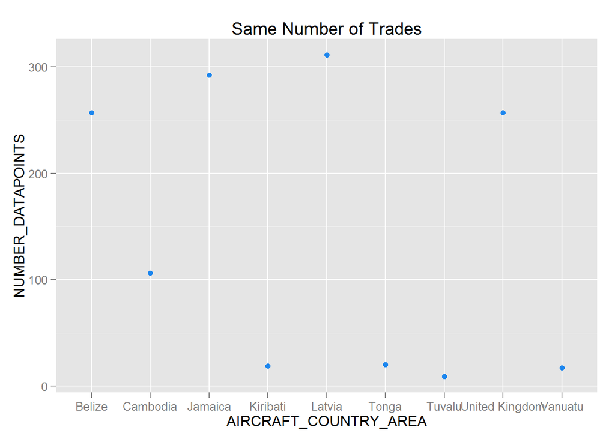

```
##
## > tradeplot1 <- ggplot(aircrafttrades, aes(x = AIRCRAFT_COUNTRY_AREA,
## +     y = NUMBER_DATAPOINTS)) + geom_area(colour = "dodgerblue2") +
## +     labs .... [TRUNCATED]
##
## > tradeplot2 <- ggplot(ammotrades, aes(x = AMMO_COUNTRY_AREA,
## +     y = NUMBER_DATAPOINTS)) + geom_area(colour = "red") + labs(x = "Number of Ammo Tr ..." ... [TRUNCATED]
##
## > tradeplot3 <- ggplot(altrades, aes(x = AL_COUNTRY_AREA,
## +     y = NUMBER_DATAPOINTS)) + geom_area(colour = "chocolate") +
## +     labs(x = "Number o ..." ... [TRUNCATED]
##
## > yearPlot1 <- ggplot(yc1, aes(x = COUNTRY, y = YEAR,
## +     color = factor(YEAR))) + geom_point() + coord_flip()
##
## > yearPlot2 <- ggplot(G3 %>% slice(100:300), aes(x = YEAR,
## +     y = COUNTRY)) + geom_line(aes(color = "Country Variety")) +
## +     geom_point(aes(co .... [TRUNCATED]
##
## > tradeplot1
```

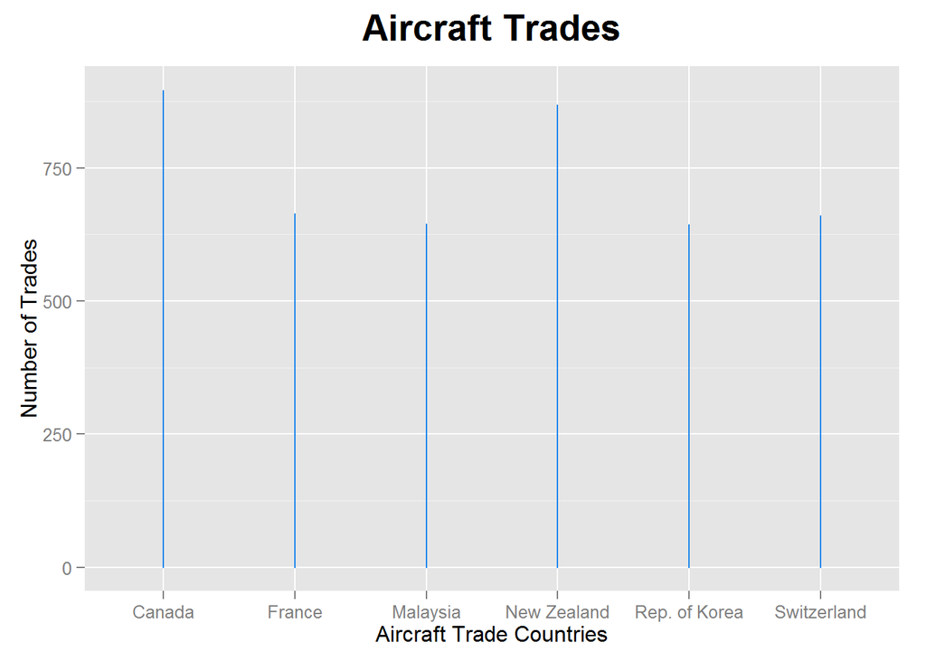

```
##
## > tradeplot2
```

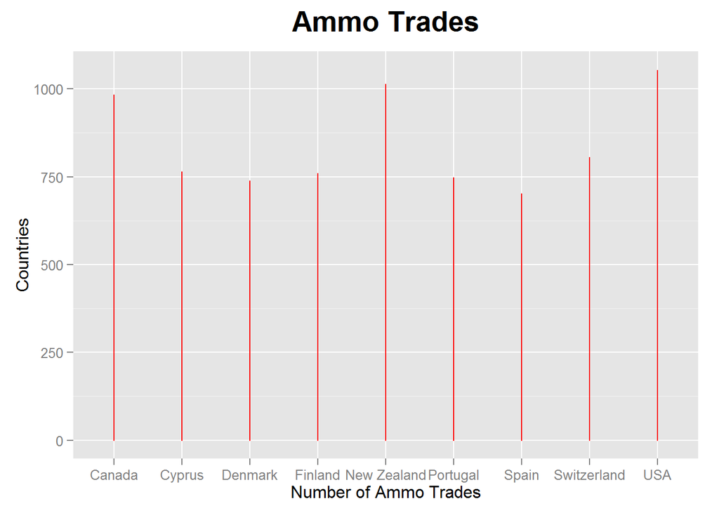

```
##
## > tradeplot3
```

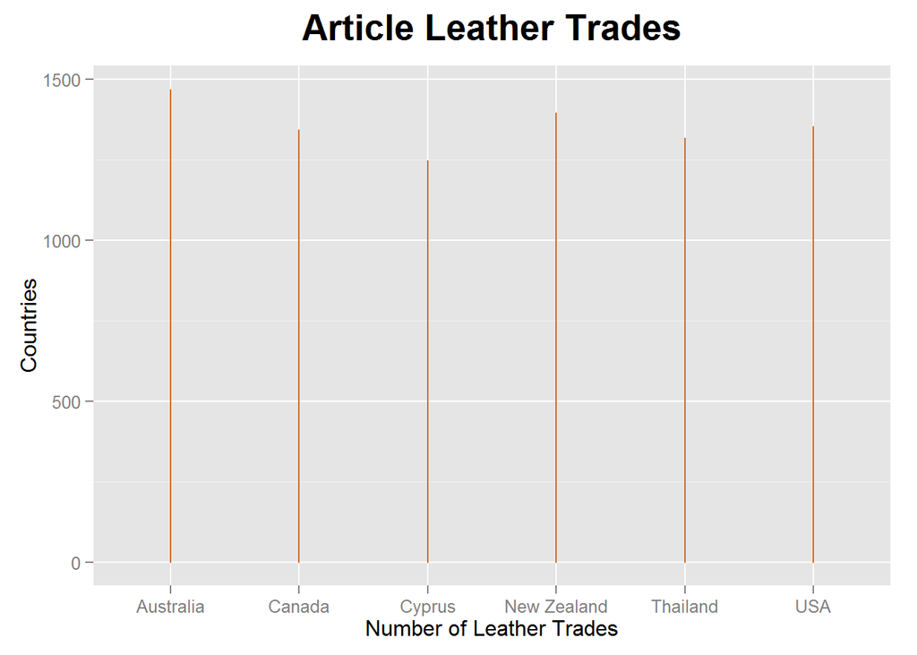

```
##
## > yearPlot1
```

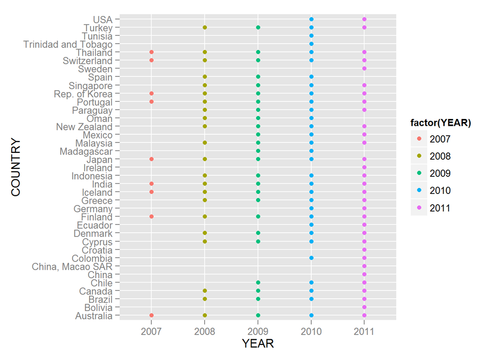

```
##
## > yearPlot2
```

```
## geom_path: Each group consist of only one observation. Do you need to adjust the group aesthetic?
```

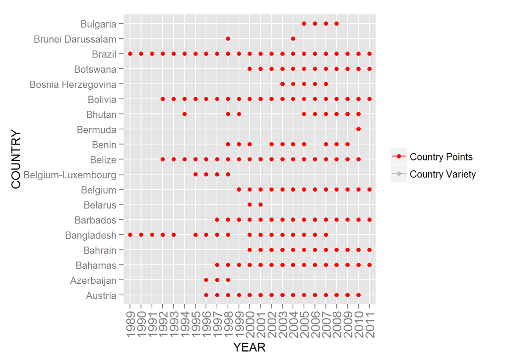

## PNG’s

The following png’s were created using the PNG.R file located in the 01 Data folder.

### categoricals.png

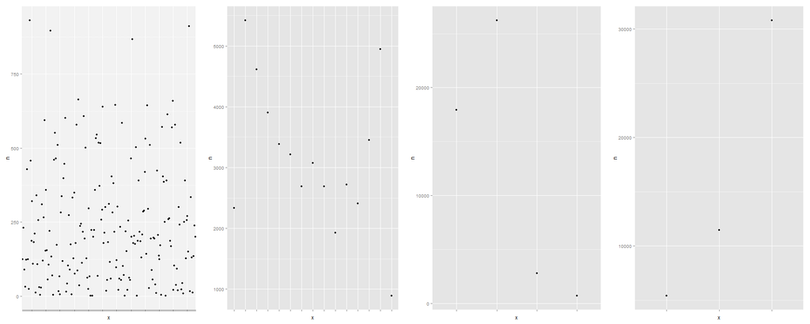

### measures.png

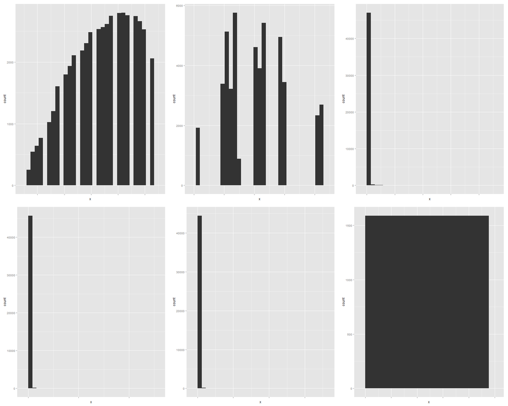